# Unsupervised Learning: Trade&Ahead

## Hierarchical Clustering

```python
df_Hier = subset_scaled_dfSD.copy()
```

```python
distance_metrics = ["euclidean", "chebyshev", "mahalanobis", "cityblock"]
linkage_methods = ["single", "complete", "average", "weighted"]
high_cophenet_corr = 0
high_dm_lm = [0, 0]
for dm in distance_metrics:
    for lm in linkage_methods:
        Z = linkage(df_Hier, metric=dm, method=lm)
        c, coph_dists = cophenet(Z, pdist(df_Hier))
        print("Cophenetic correlation for {} distance and {} linkage is {}.".format(dm.capitalize(), lm, c))
        if high_cophenet_corr < c:
            high_cophenet_corr = c
            high_dm_lm[0] = dm
            high_dm_lm[1] = lm
print('*'*100)
print("Highest cophenetic correlation is {}, which is obtained with {} distance and {} linkage.".format(high_cophenet_corr, high_dm_lm[0].capitalize(), high_dm_lm[1]))
```

```
Cophenetic correlation for Euclidean distance and single linkage is 0.9232271494002922.
Cophenetic correlation for Euclidean distance and complete linkage is 0.7873280186580672.
Cophenetic correlation for Euclidean distance and average linkage is 0.9422540609560814.
Cophenetic correlation for Euclidean distance and weighted linkage is 0.8693784298129404.
Cophenetic correlation for Chebyshev distance and single linkage is 0.9062538164750717.
Cophenetic correlation for Chebyshev distance and complete linkage is 0.598891419111242.
Cophenetic correlation for Chebyshev distance and average linkage is 0.9338265528030499.
Cophenetic correlation for Chebyshev distance and weighted linkage is 0.9127355892367.
Cophenetic correlation for Mahalanobis distance and single linkage is 0.925919553052459.
Cophenetic correlation for Mahalanobis distance and complete linkage is 0.7925307202850002.
Cophenetic correlation for Mahalanobis distance and average linkage is 0.9247324030159736.
Cophenetic correlation for Mahalanobis distance and weighted linkage is 0.8708317490180428.
Cophenetic correlation for Cityblock distance and single linkage is 0.9334186366528574.
Cophenetic correlation for Cityblock distance and complete linkage is 0.7375328863205818.
Cophenetic correlation for Cityblock distance and average linkage is 0.9302145048594667.
Cophenetic correlation for Cityblock distance and weighted linkage is 0.731045513520281.
Highest cophenetic correlation is 0.9422540609560814, which is obtained with Euclidean distance and average linkage.
```

**Euclidean Distance Only now**

```python
linkage_methods = ["single", "complete", "average", "centroid", "weighted"]
high_cophenet_corr = 0
high_dm_lm = [0, 0]
for lm in linkage_methods:
    Z = linkage(subset_scaled_dfSD, metric="euclidean", method=lm)
    c, coph_dists = cophenet(Z, pdist(subset_scaled_dfSD))
    print("Cophenetic correlation for {} linkage is {}.".format(lm, c))
    if high_cophenet_corr < c:
        high_cophenet_corr = c
        high_dm_lm[0] = "euclidean"
        high_dm_lm[1] = lm
```

```
Cophenetic correlation for single linkage is 0.9232271494002922.
Cophenetic correlation for complete linkage is 0.7873280186580672.
Cophenetic correlation for average linkage is 0.9422540609560814.
Cophenetic correlation for centroid linkage is 0.9314012446828154.
Cophenetic correlation for weighted linkage is 0.8693784298129404.
```

```python
print("Highest cophenetic correlation is {}, which is obtained with {} linkage.".format(high_cophenet_corr, high_dm_lm[1]))
```

```
Highest cophenetic correlation is 0.9422540609560814, which is obtained with average linkage.
```

- Cophenetic correlation is maximum with Euclidean distance and average linkage.

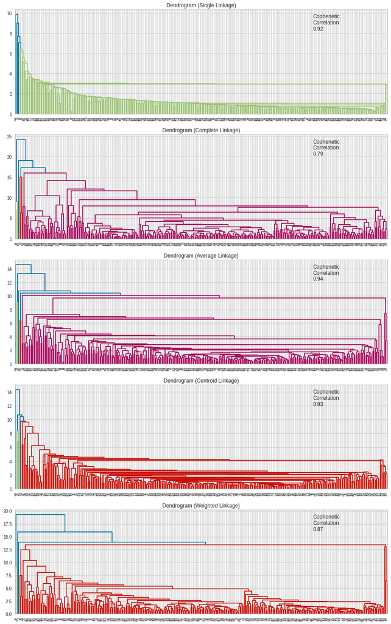

```python
inkage_methods = ["single", "complete", "average", "centroid", "weighted"]
compare_cols = ["Linkage", "Cophenetic Coefficient"]
fig, axs = plt.subplots(len(linkage_methods), 1, figsize=(15, 25))
for i, method in enumerate(linkage_methods):
    Z = linkage(subset_scaled_dfSD, metric="euclidean", method=method)
    dendrogram(Z, ax=axs[i])
    axs[i].set_title(f"Dendrogram ({method.capitalize()} Linkage)")
    coph_corr, coph_dist = cophenet(Z, pdist(subset_scaled_dfSD))
    axs[i].annotate(f"Cophenetic\nCorrelation\n{coph_corr:0.2f}",(0.80, 0.80),xycoords="axes fraction",)
```

**Creating the model**

```python
model_Hier = AgglomerativeClustering(n_clusters=6, affinity="euclidean", linkage="average")
model_Hier.fit(subset_scaled_dfSD)
```

```
AgglomerativeClustering(affinity='euclidean', linkage='average', n_clusters=6)
```

```python
df_SD2 = df_SD.copy()
df_Hier["HC_clusters"] = model_Hier.labels_
df_SD2["HC_clusters"] = model_Hier.labels_
```

**Cluster Profiling**

```python
cluster_profile = df_SD2.groupby("HC_clusters").mean()
```

```python
cluster_profile["count_in_each_segments"] = (df_SD2.groupby("HC_clusters")["Security"].count().values)
```

```python
for cl in df_SD2["HC_clusters"].unique():
    print("In cluster {}, the following companies are present:".format(cl))
    print(df_SD2[df_SD2["HC_clusters"] == cl]["Security"].unique())
    print()
```

```
In cluster 0, the following companies are present:
['American Airlines Group' 'AbbVie' 'Abbott Laboratories'
 'Adobe Systems Inc' 'Analog Devices, Inc.' 'Archer-Daniels-Midland Co'
 'Ameren Corp' 'American Electric Power' 'AFLAC Inc'
 'American International Group, Inc.' 'Apartment Investment & Mgmt'
 'Assurant Inc' 'Arthur J. Gallagher & Co.' 'Akamai Technologies Inc'
 'Albemarle Corp' 'Alaska Air Group Inc' 'Allstate Corp' 'Allegion'
 'Alexion Pharmaceuticals' 'Applied Materials Inc' 'AMETEK Inc'
 'Affiliated Managers Group Inc' 'Amgen Inc' 'Ameriprise Financial'
 'American Tower Corp A' 'Amazon.com Inc' 'AutoNation Inc' 'Anthem Inc.'
 'Aon plc' 'Anadarko Petroleum Corp' 'Amphenol Corp' 'Arconic Inc'
 'Activision Blizzard' 'AvalonBay Communities, Inc.' 'Broadcom'
 'American Water Works Company Inc' 'American Express Co' 'Boeing Company'
 'Baxter International Inc.' 'BB&T Corporation' 'Bard (C.R.) Inc.'
 'Baker Hughes Inc' 'BIOGEN IDEC Inc.' 'The Bank of New York Mellon Corp.'
 'Ball Corp' 'Bristol-Myers Squibb' 'Boston Scientific' 'BorgWarner'
 'Boston Properties' 'Citigroup Inc.' 'Caterpillar Inc.' 'Chubb Limited'
 'CBRE Group' 'Crown Castle International Corp.' 'Carnival Corp.'
 'Celgene Corp.' 'CF Industries Holdings Inc' 'Citizens Financial Group'
 'Church & Dwight' 'C. H. Robinson Worldwide' 'Charter Communications'
 'CIGNA Corp.' 'Cincinnati Financial' 'Colgate-Palmolive' 'Comerica Inc.'
 'CME Group Inc.' 'Chipotle Mexican Grill' 'Cummins Inc.' 'CMS Energy'
 'Centene Corporation' 'CenterPoint Energy' 'Capital One Financial'
 'Cabot Oil & Gas' 'The Cooper Companies' 'CSX Corp.' 'CenturyLink Inc'
 'Cognizant Technology Solutions' 'Citrix Systems' 'CVS Health'
 'Chevron Corp.' 'Concho Resources' 'Dominion Resources' 'Delta Air Lines'
 'Du Pont (E.I.)' 'Deere & Co.' 'Discover Financial Services'
 'Quest Diagnostics' 'Danaher Corp.' 'The Walt Disney Company'
 'Discovery Communications-A' 'Discovery Communications-C'
 'Delphi Automotive' 'Digital Realty Trust' 'Dun & Bradstreet'
 'Dover Corp.' 'Dr Pepper Snapple Group' 'Duke Energy' 'DaVita Inc.'
 'Devon Energy Corp.' 'eBay Inc.' 'Ecolab Inc.' 'Consolidated Edison'
 'Equifax Inc.' "Edison Int'l" 'Eastman Chemical' 'EOG Resources'
 'Equinix' 'Equity Residential' 'EQT Corporation' 'Eversource Energy'
 'Essex Property Trust, Inc.' 'E*Trade' 'Eaton Corporation'
 'Entergy Corp.' 'Edwards Lifesciences' 'Exelon Corp.' "Expeditors Int'l"
 'Expedia Inc.' 'Extra Space Storage' 'Ford Motor' 'Fastenal Co'
 'Fortune Brands Home & Security' 'Freeport-McMoran Cp & Gld'
 'FirstEnergy Corp' 'Fidelity National Information Services' 'Fiserv Inc'
 'FLIR Systems' 'Fluor Corp.' 'Flowserve Corporation' 'FMC Corporation'
```

[output cut: 65 more lines]

```

In cluster 5, the following companies are present:
['Alliance Data Systems']

In cluster 2, the following companies are present:
['Apache Corporation' 'Chesapeake Energy']

In cluster 1, the following companies are present:
['Bank of America Corp' 'Intel Corp.']

In cluster 3, the following companies are present:
['Facebook']

In cluster 4, the following companies are present:
['Priceline.com Inc']
```

- We see there are three clusters of only 1 company, two clusters of 2 companies and the rest grouped into another cluster. There is no variability here.

```python
df_SD2.groupby(["HC_clusters", "GICS Sector"])['Security'].count()
```

```
HC_clusters  GICS Sector
0            Consumer Discretionary         39
             Consumer Staples               19
             Energy                         28
             Financials                     48
             Health Care                    40
             Industrials                    53
             Information Technology         30
             Materials                      20
             Real Estate                    27
             Telecommunications Services     5
             Utilities                      24
1            Financials                      1
             Information Technology          1
2            Energy                          2
3            Information Technology          1
4            Consumer Discretionary          1
5            Information Technology          1
Name: Security, dtype: int64
```

```python
cluster_profile.style.highlight_max(color="yellow", axis=0)
```

| HC_clusters | Current Price | Price Change | Volatility | ROE | Cash Ratio | Net Cash Flow | Net Income | Earnings Per Share | Estimated Shares Outstanding | P/E Ratio | P/B Ratio | count_in_each_segments |
| --- | --- | --- | --- | --- | --- | --- | --- | --- | --- | --- | --- | --- |
| 0 | 77.287589 | 4.099730 | 1.518066 | 35.336336 | 66.900901 | -33197321.321321 | 1538074666.666667 | 2.885270 | 560505037.293544 | 32.441706 | -2.174921 | 333 |
| 1 | 25.640000 | 11.237908 | 1.322355 | 12.500000 | 130.500000 | 16755500000.000000 | 13654000000.000000 | 3.295000 | 2791829362.100000 | 13.649696 | 1.508484 | 2 |
| 2 | 24.485001 | -13.351992 | 3.482611 | 802.000000 | 51.000000 | -1292500000.000000 | -19106500000.000000 | -41.815000 | 519573983.250000 | 60.748608 | 1.565141 | 2 |
| 3 | 104.660004 | 16.224320 | 1.320606 | 8.000000 | 958.000000 | 592000000.000000 | 3669000000.000000 | 1.310000 | 2800763359.000000 | 79.893133 | 5.884467 | 1 |
| 4 | 1274.949951 | 3.190527 | 1.268340 | 29.000000 | 184.000000 | -1671386000.000000 | 2551360000.000000 | 50.090000 | 50935516.070000 | 25.453183 | -1.052429 | 1 |
| 5 | 276.570007 | 6.189286 | 1.116976 | 30.000000 | 25.000000 | 90885000.000000 | 596541000.000000 | 8.910000 | 66951851.850000 | 31.040405 | 129.064585 | 1 |

## Actionable Insights and Recommendations

- Cluster 1 contains the best companies which has the highest Net cash flow and Net income, while having moderate ROE and moderate Price change. Companies looking to imporove their business or the consumer looking to invest their money should look into these companies.
- Cluster 0 contains moderate companies all across the baord. They have moderate Net incomes, cash flow, price change and ROE. These would be the safe companies to invest in or model after.
- Cluster 2 contains only 2 company but it contains the highest in volatility, ROE. These companies would not be suitable to model after as their Net Income and Net cash flow are negative.
- Cluster 3 contains only 1 company but it has the highest Price change, cash ratio estimated hsares outstanding and P/E ratio. While it does only have moderate Net cash flow and Net income this company would be good to model after and invest in.
- Cluster 4 contains the company with the highest current price and earnings per share, but they also have a negative net cash flow and moderate netincome and ROE. So this company would be an ok company to model after.
- Clster 5 contains a company with the highest P/B ratio but moderate in every other category. This would also be an okay company to model after and invest in but not the best.

```python
%%shell
jupyter nbconvert --to html ///content/drive/MyDrive/DSBA_Project_ET_EasyVisa_Fullcode.ipynb
```

[output not shown]

[output cut: 134 more lines]

[output not shown]

[output not shown]